# Cyber Security: Safety At Home, Online, and in Life

Varsha Venkataraman - 240150459

2024-11-11

This report investigates and provides insights on the dataset collected for the Cyber Security: (Safety At Home, Online, and in Life) course developed by Newcastle University and offered by the Future Learn Platfrom which is a massive open online course (MOOC). The course is 3 weeks long and was free to access.

The university course team are likely to find some value from this report, with the main beneficiaries being the online course providers. The framework that is used to provide the results and conclusions in the report is the Cross Industry Standard for Data Mining (CRISP-DM), performing two cycles of the model to produce the results which follow.

The investigation can provide them in framing the upcoming course structure or modify the existing ones, and rectify the existing issues they are facing with learners.

The main objective of the report is to identify the areas where the university can improve in getting the right choice of learners and improve the course modules so that the course will also be popular and effective.

With the primary objective in the mind the first question which this report aims to answer is:

What is the distribution of employment areas among learners enrolled in the Cyber Security course, and are there any missing data which is in high proportion that affect the insights?

For phase 1 of CRISP-DM,the data set that has the details of learners such as the learner id, employment area, are the primary columns required. The cyber security enrollments file for each period are considered primarily for the first research question.

After gathering the dataset the next step is to investigate for any data issues. This step is to avoid any potential issues that might arise when we start with the analysis part, Hence its necessary to clean and pre process the dataset as per our requirement.

When I explored the cyber security enrollment files for the cyber security for different time frames. The dataset contained learners Id and their specific ‘employment_area’, ‘highest_education_level’ and few more details. But, there were lots of ‘Unknown’ values in many rows and columns. The ‘Unknowns’ values created the data to be more weaker to come up with a conclusion as these values cannot be assumed or filled with methods to fill the missing entries.

Few columns had ‘Unknown’ as a value , but column like ‘purchased_statement_at’ have many missing data in it and the rows were also left blank. Categorical fields like these are difficult to be filled with data, and we need to consider them to be ‘NA’ or ‘Unknown’.

Also, there were repeated learners id , initialy I considered it to be a primary key but when I saw it to be repeated, a doubt of duplicates araised. But, further exploring the repeated values along with its enrolled date, a clear understanding was made that the learners rejoined the course at various intervals.

The data preparations included five steps in total. The steps includes data collection, data cleaning , data integration, data transformation and selecting the data in preparation for the modelling phase to come next.

The data gathered for this research was sourced from Future Learn. The Learner IDs allow for combining of information between different data sheets. The data is collected for the cyber security course for a specific period so there seven different time frames in which the data is collected.

The data has all the primary deatils of the learners who joined the course in different time frames, and their specific enrollment time along with their employment area is also gathered.

Data wrangling is a more specific part of data preparation, focusing on cleaning, restructuring, and transforming raw data into a more useful format whic includes the below steps.

In data cleaning, I filtered out the required columns alone and removed the unwanted columns from the dataset. In the enrollment file , I only considered ‘learner_id’, ‘employment_area’ and eliminated rest of the columns. The reason to consider these specific columns is because the learner_id from which i will get very unique information about the learners and it will act as a primary key here. The employment area is considered as my research question is bounded by it and I will need to do every analysis considering the employment area of the learner

I also replaced the empty rows with ‘NA’ for uniformity and to fill the blank space. Here we are not able to follow any of the methods such as to replace with mean , mode or median for the missing datas as all are unique values and its hard to follow any of the existing methods to replace hence went with the way of filling it with the unknown value.

NA is a standardized way to represent missing data in R (and other statistical tools). Most functions that handle missing data recognize NA, making data processing more seamless. Using “Unknown” as a placeholder may lead to misinterpretation by functions that expect missing values as NA. Most statistical models, transformations, and data wrangling techniques treat NA values appropriately, either by ignoring or imputing them as necessary. Having “Unknown” in place of NA might bias analyses, as it’s recognized as text rather than as a missing value.

In this part, I re-coded the employment_area row values with standardized categorical labels. This transformation is usually done when you want to standardize or simplify categorical values, making them easier to analyze or interpret.

| Old Value | New Value | Old Value | New Value |
| --- | --- | --- | --- |
| accountancy_banking_and_finance | Finance | law | Law |
| armed_forces_and_emergency_services | Defense | marketing_advertising_and_pr | Marketing |
| business_consulting_and_management | Consulting | media_and_publishing | Media |
| charities_and_voluntary_work | Charity | property_and_construction | Construction |
| creative_arts_and_culture | Arts | public_sector | Public |
| energy_and_utilities | Energy | recruitment_and_pr | Recruitment |
| engineering_and_manufacturing | Engineering | retail_and_sales | Retail |
| environment_and_agriculture | Environment | science_and_pharmaceuticals | Science |
| health_and_social_care | Healthcare | teaching_and_education | Education |
| hospitality_tourism_and_sport | Hospitality | transport_and_logistics | Logistics |
| it_and_information_services | IT |  |  |

For the first research question, its important to have learners id,and to find distribution of employment area of the learners we need to consider the employment area feature. So rest fields are optional for this research question hence removed them for further analysis.

From the visualization we can conclude that the learners from IT industry has the maximum enrollment and the learners from the recruitment industry has the least enrollment. It is very obvious that the IT field is related to the course, but its surprising that the Finance area is standing seventh in the column.

The cyber security has important role in the finance and banking area as many fraudulent acts occurs in this area.

The second bar plot titled ‘Number of rejoiners by Employment Area’ depicts the maximum number of rejoiners from different employment area. Its very evident that its from ‘IT’ field there are maximum number of rejoiners. Also, the number of rejoiners is not propotional to the number of enrollments in the course base on employment area.

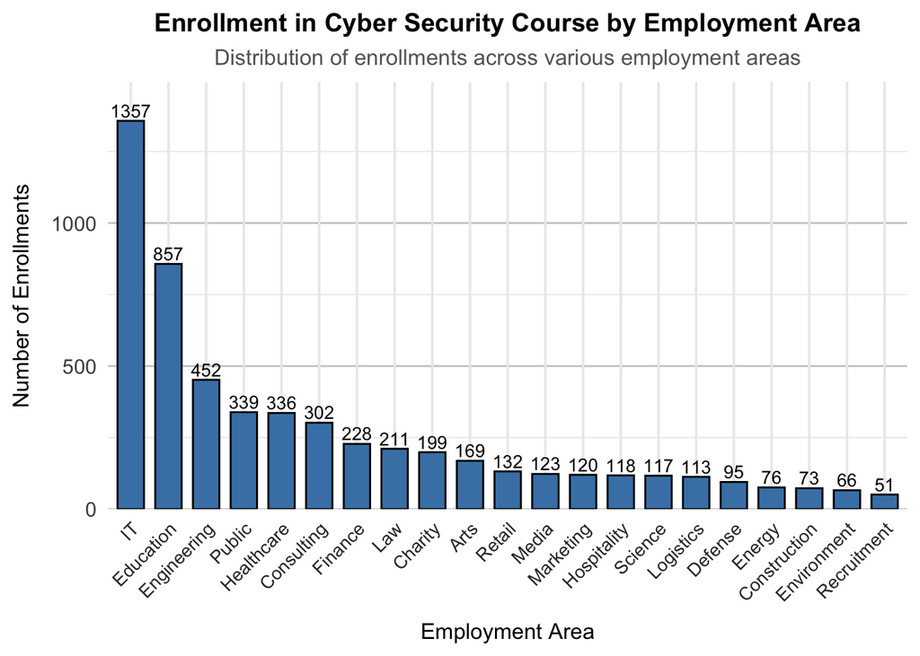

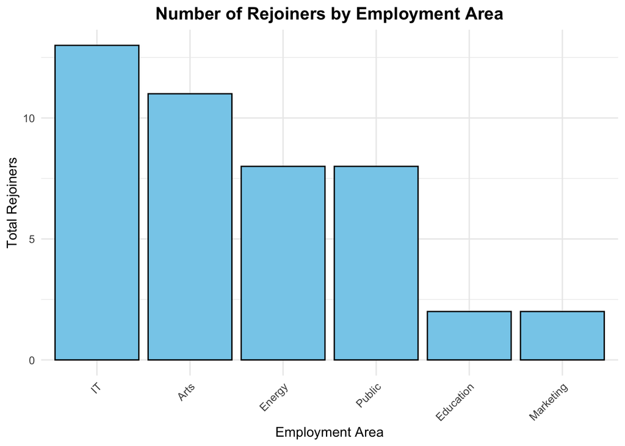

Learner Metrics

| Metric | Value | Metric | Value |
| --- | --- | --- | --- |
| Total Learners | 63248 | Unique Learners | 35225 |

With respect to the above Table 1, the total number of learners who are enrolled in the cyber security course is 63,248 of them. Looking at the pie chart below which has the percentage value for the learners per employment area. We can conclude that we have the employment area information only for 9% of the learners only.

The remaining 91% (roughly 57,556 learners) do not have employment area information. Because of which we cannot come up with 100% accuracy which area of employers take up this cyber security course.

There are around 63,248 learners with respect to the Table 1, who enrolled altogether in the cyber security course. But the unique number of learners are only 35,225 according to Table 1. Which means the rest 28,023 are either duplicate or re-joiners.

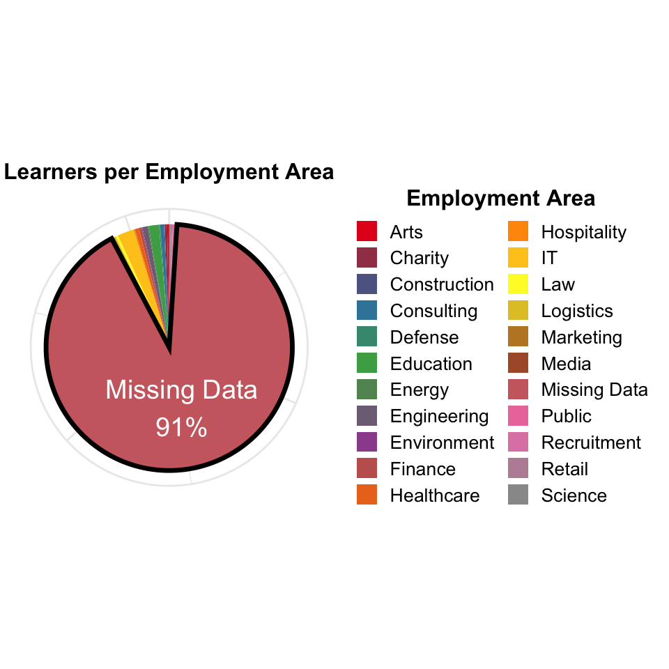

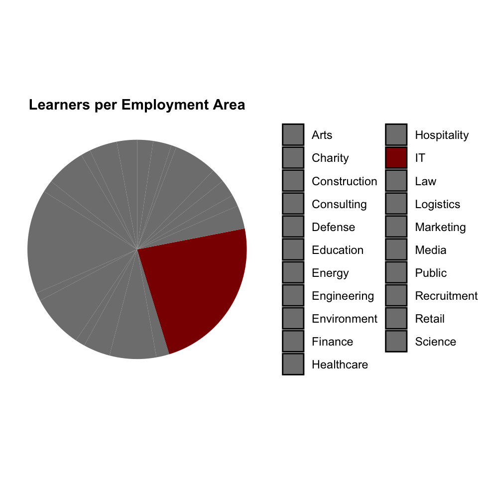

The goal of first research question is not completely achieved as there are 91% of missing data so we cannot come to a conclusion with cent percent accuracy that the IT industry has the most number of learners for the cyber security course. With the dataset we have excluding the missing data, we can make a conclusion that the IT industry has the maximum distribution of learners.

We need to ensure to have the enrollment details completely collected before enrolling and starting with the course, as it is always necessary to have the basic enrollment details of the learners.

With the secondary objective of the report, I am investigating on number of re-joiners, I am trying to understand the reason for them to quit and rejoin. Also, to gain some insights so that we can avoid re-joiners and modify the course modules accordingly to make it efficient to complete in the first schedule, if the reasons are stated because of the course structure.

What is the primary reason for re-enrollment based on the employment area? What potential improvement can be done to the course to help learners complete the course without rejoining?

For phase 2 of CRISP-DM, to make an analysis for the number of re-joiners I first need to know the count of re-joiners and their duplicate learners id. Also, to know the primary reason to leave the course its required to gather the unique reasons stated by the learners to quit. So for this I am considering the leaving_survey_response data and also the course enrollment data.

Firstly, the course enrollment data is analysed in the first cycle and number of unique and repeated learners count is gathered. Looking into the leaving_survey_response data we can gather the unique reasons for the learners to leave the course.

In data cleaning, I filtered out the required columns alone and removed the unwanted columns from the dataset. In the survey response file , I only considered ‘learner_id’, ‘left_at’, ‘leaving_reason’ and eliminated rest of the columns.

Moreover the first three leaving-survey-responses files did not even have any datas the file size was less in bytes. So, I did not consider these files and started with the files that had data.

I also replaced the empty rows with ‘NA’ for uniformity and to fill the blank space and aslo as stated in the first cycle its pretty easier to use built in functions. Here we are not able to follow any of the methods such as to replace with mean , mode or median for the missing datas as all are unique values and its hard to follow any of the existing methods to replace hence went with the way of filling it with the unknown value.

For this research question, its important to have learners id,and to find the reason for them to leave we need to have the ‘leaving_reasons’ field. So rest fields are optional for this research question hence removed them for further analysis.

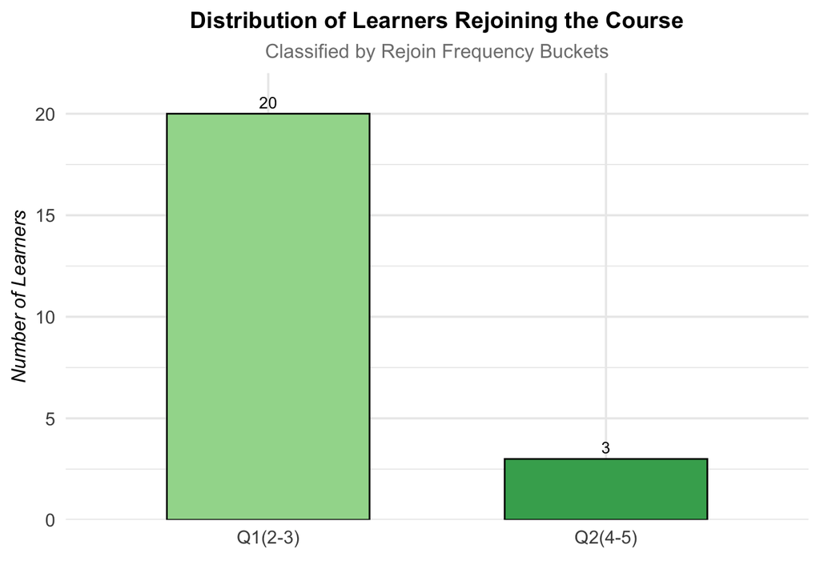

Since there are many number of re-joiners for the cyber security course. Now, looking at the survey response collected from the learners for leaving the course I have tabled number of learners reasons to leave the course with unique reasons and its total count chosen by the learners.

Since, the maximum reason was time constraints, I calculated the total hours taken for the course to be completed it is 50.05. Hence one main action by the course team need to take into consideration is to reduce the total time taken for the completion. Keeping in mind there are a lot of missing datas, we need to specifically see the reason to leave the course by the learners particularly from each employment area.

[figure not shown]

In conclusion it is stated that most of the learners feel that the course is very lengthy that they do not find enough time to complete. Which is why they are re-joining it or maybe the course is framed perfect its the learners are not able to frame time for learning.

If this total course time is minimized or divided as 25 hours for video materials and the rest modules as pdf or document to self study it might minimize the learners to leave the course.

Since, more learners are from ‘IT’ field we can collect the form as why the course is hard and why it did not meet their expectations with which we can proceed to alter the modules.

The final phase of this CRISP-DM is the deployment which includes the analysis and also my presentation for the insights derived from the dataset given, hoping this will add up value to the course and also help the stakeholders to improve the course modules and rectify the existing issues.

These informative graphics will help the stakeholders to come up with an idea to resolve the existing issues and enhance the course for a better level.